# Chapter 3: Data Manipulation with Pandas

## Pivot Tables by Hand

Let’s compare survival rates for men and women:

```python
(
  titanic
  .groupby("sex")[["survived"]]
  .mean()
)
```

```
        survived
sex
female  0.742038
male    0.188908
```

Let’s compare the survival rates for sex and class:

```python
(
  titanic
  .groupby(["sex", "class"])["survived"]
  .mean()
  .unstack()
)
```

```
class      First    Second     Third
sex
female  0.968085  0.921053  0.500000
male    0.368852  0.157407  0.135447
```

## Pivot Table Syntax

Here is the equivalent to the preceding operation using the `pivot_table` method of DataFrames:

```python
(
  titanic
  .pivot_table("survived", index = "sex", columns = "class")
)
```

```
class      First    Second     Third
sex
female  0.968085  0.921053  0.500000
male    0.368852  0.157407  0.135447
```

### Multi-level pivot tables

Pivot tables can be specified with multiple levels. For example, we might be interested in looking at age as a third dimension:

```python
(
  titanic
  .assign(age = lambda x: pd.cut(titanic["age"], [0, 18, 80]))
  .pivot_table("survived", ["sex", "age"], "class")
)
```

```
class               First    Second     Third
sex    age
female (0, 18]   0.909091  1.000000  0.511628
       (18, 80]  0.972973  0.900000  0.423729
male   (0, 18]   0.800000  0.600000  0.215686
       (18, 80]  0.375000  0.071429  0.133663
```

We can also add in information to the columns:

```python
(
  titanic
  .assign(age = lambda x: pd.cut(titanic["age"], [0, 18, 80]),
          fare = lambda x: pd.qcut(titanic["fare"], 2))
  .pivot_table("survived", ["sex", "age"], ["fare", "class"])
)
```

```
fare            (-0.001, 14.454]            ... (14.454, 512.329]
class                      First    Second  ...            Second     Third
sex    age                                  ...
female (0, 18]               NaN  1.000000  ...          1.000000  0.318182
       (18, 80]              NaN  0.880000  ...          0.914286  0.391304
male   (0, 18]               NaN  0.000000  ...          0.818182  0.178571
       (18, 80]              0.0  0.098039  ...          0.030303  0.192308

[4 rows x 6 columns]
```

### Additional pivot table options

```python
# call signature as of Pandas 0.18
DataFrame.pivot_table(data, values=None, index=None, columns=None,
                      aggfunc='mean', fill_value=None, margins=False,
                      dropna=True, margins_name='All')
```

[output not shown]

## Example: Birthrate Data

Let’s look at birthrate data as another example.

```python
birth_data = pd.read_csv("https://raw.githubusercontent.com/jakevdp/data-CDCbirths/master/births.csv")

birth_data.head()
```

```
   year  month  day gender  births
0  1969      1  1.0      F    4046
1  1969      1  1.0      M    4440
2  1969      1  2.0      F    4454
3  1969      1  2.0      M    4548
4  1969      1  3.0      F    4548
```

Let’s investigate the data with a pivot table. We’ll add a decade column and look at male and female births as a function of decade:

```python
(
  birth_data
  .assign(decade = lambda x: 10 * (birth_data["year"] // 10))
  .pivot_table("births", index = "decade", columns = "gender", aggfunc = "sum")
)
```

```
gender         F         M
decade
1960     1753634   1846572
1970    16263075  17121550
1980    18310351  19243452
1990    19479454  20420553
2000    18229309  19106428
```

Let’s visualize total births by year:

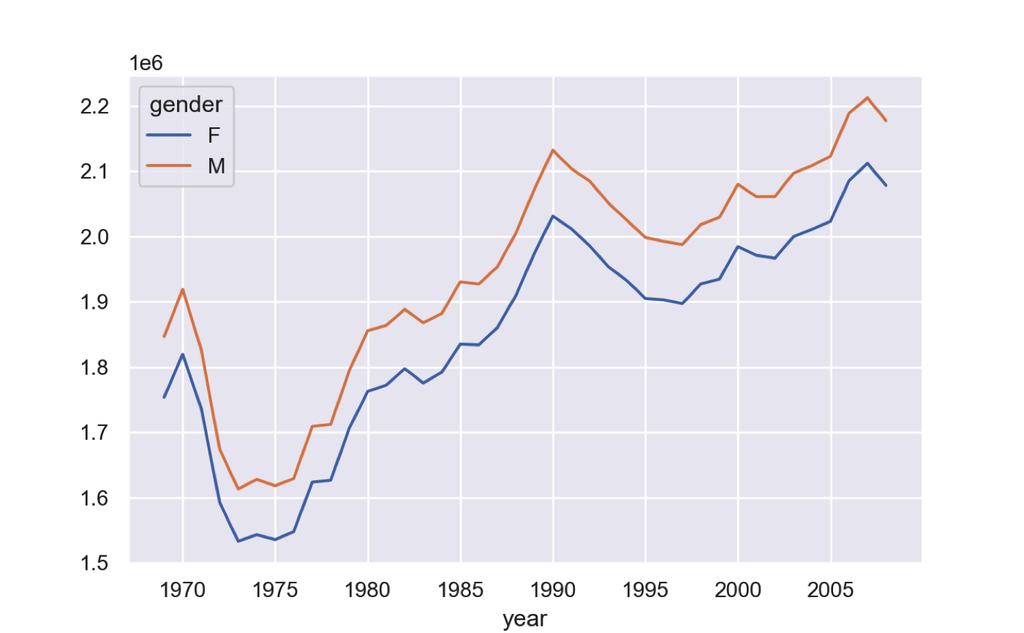

```python
import matplotlib.pyplot as plt
sns.set()

(
  birth_data
  .assign(decade = lambda x: 10 * (birth_data["year"] // 10))
  .pivot_table("births", index = "year", columns = "gender", aggfunc = "sum")
  .plot()
)
plt.show()
```

```python
plt.clf()
```

# Vectorized String Operations

## Introducing Pandas String Operations

Pandas provides the functionality for vectorized string operations. For example:

```python
import pandas as pd

data = ['peter', 'Paul', 'MARY', 'gUIDO']
names = pd.Series(data)
names
```

```
0    peter
1     Paul
2     MARY
3    gUIDO
dtype: object
```

```python
names.str.capitalize()
```

```
0    Peter
1     Paul
2     Mary
3    Guido
dtype: object
```

## Tables of Pandas String Methods

```python
monte = pd.Series(['Graham Chapman', 'John Cleese', 'Terry Gilliam',
                   'Eric Idle', 'Terry Jones', 'Michael Palin'])
```

### Methods similar to Pythons string methods

| `len()` | `lower()` | `translate()` | `islower()` |
| --- | --- | --- | --- |
| `ljust()` | `upper()` | `startswith()` | `isupper()` |
| `rjust()` | `find()` | `endswith()` | `isnumeric()` |
| `center()` | `rfind()` | `isalnum()` | `isdecimal()` |
| `zfill()` | `index()` | `isalpha()` | `split()` |
| `strip()` | `rindex()` | `isdigit()` | `rsplit()` |
| `rstrip()` | `capitalize()` | `isspace()` | `partition()` |
| `lstrip()` | `swapcase()` | `istitle()` | `rpartition()` |

```python
monte.str.lower()
```

```
0    graham chapman
1       john cleese
2     terry gilliam
3         eric idle
4       terry jones
5     michael palin
dtype: object
```

```python
monte.str.len()
```

```
0    14
1    11
2    13
3     9
4    11
5    13
dtype: int64
```

```python
monte.str.startswith("T")
```

```
0    False
1    False
2     True
3    False
4     True
5    False
dtype: bool
```

```python
monte.str.split()
```

```
0    [Graham, Chapman]
1       [John, Cleese]
2     [Terry, Gilliam]
3         [Eric, Idle]
4       [Terry, Jones]
5     [Michael, Palin]
dtype: object
```

### Methods using regular expressions

There are several methods that accept regular expressions to examine the content of each string element:

| Method | Description |
| --- | --- |
| `match()` | Call `re.match()` on each element, returning a boolean. |
| `extract()` | Call `re.match()` on each element, returning matched groups as strings. |
| `findall()` | Call `re.findall()` on each element |
| `replace()` | Replace occurrences of pattern with some other string |
| `contains()` | Call `re.search()` on each element, returning a boolean |
| `count()` | Count occurrences of pattern |
| `split()` | Equivalent to `str.split()`, but accepts regexps |
| `rsplit()` | Equivalent to `str.rsplit()`, but accepts regexps |

Using these, we can do things like extract the first name from each by asking for a contiguous group of characters at the beginning of each element:

```python
monte.str.extract("([A-Za-z]+)", expand = False)
```

[output not shown]

Or we can find all the names that start and end with a consonant with the start-of-string (`^`) and end-of-string (`$`):

```python
monte.str.findall(r"^[^AEIOU].*[^aeiou]$")
```

[output not shown]

### Miscellaneous methods

| Method | Description |
| --- | --- |
| `get()` | Index each element |
| `slice()` | Slice each element |
| `slice_replace()` | Replace slice in each element with passed value |
| `cat()` | Concatenate strings |
| `repeat()` | Repeat values |
| `normalize()` | Return Unicode form of string |
| `pad()` | Add whitespace to left, right, or both sides of strings |
| `wrap()` | Split long strings into lines with length less than a given width |
| `join()` | Join strings in each element of the Series with passed separator |
| `get_dummies()` | extract dummy variables as a dataframe |

#### Vectorized item access and slicing

You can slice the first three characters of each array using `str.slice(0, 3)`

```python
monte.str[0:3]

monte.str.slice(0, 3)
```

[output not shown]

#### Indicator variables

The `get_dummies()` method is useful when your data has a column containing some sort of coded indicator.

```python
full_monte = pd.DataFrame({'name': monte,
                           'info': ['B|C|D', 'B|D', 'A|C',
                                    'B|D', 'B|C', 'B|C|D']})
full_monte

full_monte["info"].str.get_dummies("|")
```

[output not shown]

## Example: Recipe Database

# Working with Time Series

Pandas has numerous tools for working with date and time data:

- *Time stamps* reference particular moments in time
- *Time intervals* and *periods* reference a length of time between a particular beginning and end point
- *Time deltas* or *durations* reference an exact length of time

## Dates and Times in Python

### Native Python dates and time: `datetime` and `dateutil`

The `datetime` module allows you to work with dates in native Python:

```python
from datetime import datetime
datetime(year = 2015, month = 7, day = 4)
```

You can parse dates from a variety of time formats using `dateutil`:

```python
from dateutil import parser
date = parser.parse("4th of July, 2015")
date
```

### Typed arrays of time: NumPy’s `datetime64`

```python
import numpy as np
date = np.array("2015-07-04", dtype = np.datetime64)
date
```

With this, we can perform vectorized operations:

```python
date + np.arange(12)
```

[output not shown]

Here is a table of the available format codes:

[output not shown]

### Dates and times in pandas: best of both worlds

Pandas provides a `Timestamp` object. With the Pandas tools, we can parse a formatted string date and use format codes to output the day of the week:

```python
import pandas as pd
date = pd.to_datetime("4th of July, 2015")
date

date.strftime("%A")
```

[output not shown]

We can also do NumPy-style operations:

```python
import numpy as np
date + pd.to_timedelta(np.arange(12), "D")
```

## Pandas Time Series: Indexing by Time

Pandas time series tools become useful when you index data by timestamps:

```python
index = pd.DatetimeIndex(["2014-07-04", "2014-08-04", "2015-07-04",
                           "2015-08-04"])
data = pd.Series([0, 1, 2, 3], index = index)
data
```

## Pandas Time Series Data Structures

- For *time stamps*, Pandas provides the `Timestamp` type. As mentioned before, it is essentially a replacement for Python’s native `datetime`, but is based on the more efficient `numpy.datetime64` data type. The associated Index structure is `DatetimeIndex`.
- For *time Periods*, Pandas provides the `Period` type. This encodes a fixed-frequency interval based on `numpy.datetime64`. The associated index structure is `PeriodIndex`.
- For *time deltas* or *durations*, Pandas provides the `Timedelta` type. `Timedelta` is a more efficient replacement for Python’s native `datetime.timedelta` type, and is based on `numpy.timedelta64`. The associated index structure is `TimedeltaIndex`.

```python
dates = pd.to_datetime([datetime(2015, 7, 3), '4th of July, 2015',
                       '2015-Jul-6', '07-07-2015', '20150708'])
dates
```

### Regular sequences: `pd.date_range()`

We can create a regular sequence of dates like this:

```python
pd.date_range("2015-07-03", "2015-07-10")
```

[output not shown]

Instead of specifying the start and end point, we can use a number of periods:

```python
pd.date_range("2015-07-03", periods = 8)
```

The interval can be modified with the `freq` argument:

```python
pd.date_range("2015-07-03", periods = 8, freq = "H")
```

## Frequencies and Offsets

| Code | Description | Code | Description |
| --- | --- | --- | --- |
| `D` | Calendar day | `B` | Business day |
| `W` | Weekly |  |  |
| `M` | Month end | `BM` | Business month end |
| `Q` | Quarter end | `BQ` | Business quarter end |
| `A` | Year end | `BA` | Business year end |
| `H` | Hours | `BH` | Business hours |
| `T` | Minutes |  |  |
| `S` | Seconds |  |  |
| `L` | Milliseonds |  |  |
| `U` | Microseconds |  |  |
| `N` | nanoseconds |  |  |

## Resampling, Shifting, and Windowing

We can import financial data with `pandas-datareader`:

```python
from pandas_datareader import data

google = data.DataReader("GOOG", start = "2004", end = "2016",
                         data_source = "google")
google.head()
```

## Example: Visualizing Seattle Bicycle Counts

```python
data = pd.read_csv("data/Fremont_Bridge_Bicycle_Counter.csv",
                   index_col = "Date",
                   parse_dates = True)
data.head()
```

Let’s shorten the columns names:

```python
data.columns = ["Total", "West", "East"]
data

data.dropna().describe()
```

### Visualizing the data

```python
import seaborn; seaborn.set()
import matplotlib.pyplot as plt

data.plot()
plt.show()
plt.clf()
```

[output not shown]

Let’s resample the data to a coarser grid:

```python
weekly = data.resample("W").sum()

weekly.plot(style = [":", "--", "-"])
plt.ylabel("Weekly bicycle count");
plt.show()
plt.clf()
```

[output not shown]

```python
daily = (data
  .resample("D")
  .sum()
  .rolling(30, center = True)
  .sum()
  .plot(style = [":", "--", "-"])
)
plt.ylabel("mean hourly count")
plt.show()
plt.clf()
```

[output not shown]

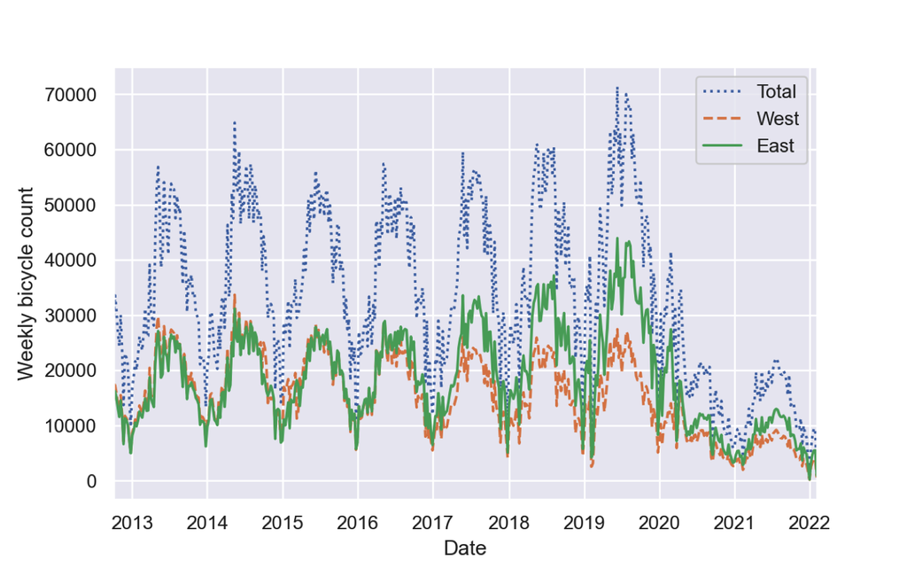

```python
weekly = data.resample("W").sum()

weekly.plot(style = [":", "--", "-"])
plt.ylabel("Weekly bicycle count");
plt.show()
```

```python
plt.clf()
```

### Digging into the data

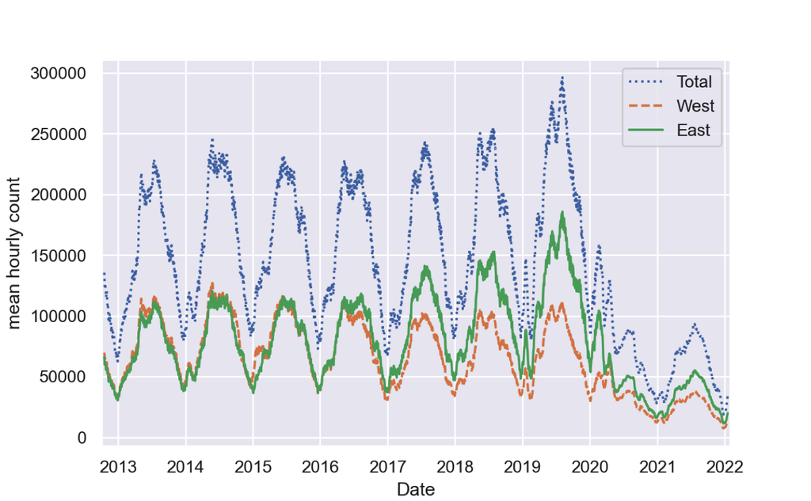

```python
daily = (data
  .resample("D")
  .sum()
  .rolling(30, center = True)
  .sum()
  .plot(style = [":", "--", "-"])
)
plt.ylabel("mean hourly count")
plt.show()
```

```python
plt.clf()
```

How does traffic look across week days?

```python
by_weekday = (
  data
  .groupby(data.index.dayofweek)
  .mean()
)

by_weekday.index = ["Mon", "Tues", "Wed", "Thurs", "Fri", "Sat", "Sun"]

by_weekday.plot(style = [":", "--", "-"])
plt.show()
plt.clf()
```

[output not shown]

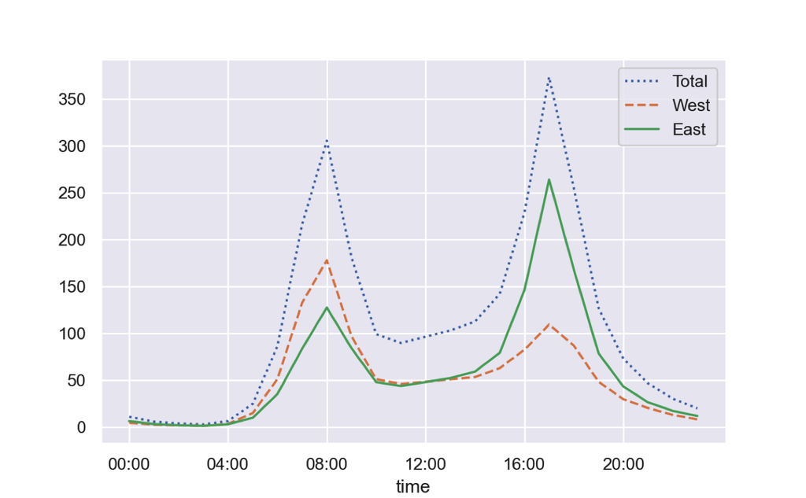

```python
by_time = (
  data
  .groupby(data.index.time)
  .mean()
)

hourly_ticks = 4 * 60 * 60 * np.arange(6)

by_time.plot(xticks = hourly_ticks, style = [":", "--", "-"])
plt.show()
```

```python
plt.clf()
```

# High-Performance Pandas: `eval()` and `query()`

## Motivating `query()` and `eval()`: Compound Expressions

## `pandas.eval()` for Efficient Operations

The `eval()` function in Pandas uses string expression to efficiently compute operations using `DataFrame`s:

```python
import pandas as pd
nrows, ncols = 100000, 100
rng = np.random.RandomState(42)
df1, df2, df3, df4 = (pd.DataFrame(rng.rand(nrows, ncols))
                      for i in range(4))
```